# AE 16: Forest classification 🌳🌲

Suggested answers

We will use **tidyverse** and **tidymodels** for data exploration and modeling, respectively, and the **forested** package for the data.

```r
library(tidyverse)
library(tidymodels)
library(forested)
```

Remember from the lecture that the `forested` dataset contains information on whether a plot is forested (`Yes`) or not (`No`) as well as numerical and categorical features of that plot.

```r
glimpse(forested)
```

```
Rows: 7,107
Columns: 19
$ forested         <fct> Yes, Yes, No, Yes, Yes, Yes, Yes, Yes, Yes, Yes, Yes,…
$ year             <dbl> 2005, 2005, 2005, 2005, 2005, 2005, 2005, 2005, 2005,…
$ elevation        <dbl> 881, 113, 164, 299, 806, 736, 636, 224, 52, 2240, 104…
$ eastness         <dbl> 90, -25, -84, 93, 47, -27, -48, -65, -62, -67, 96, -4…
$ northness        <dbl> 43, 96, 53, 34, -88, -96, 87, -75, 78, -74, -26, 86, …
$ roughness        <dbl> 63, 30, 13, 6, 35, 53, 3, 9, 42, 99, 51, 190, 95, 212…
$ tree_no_tree     <fct> Tree, Tree, Tree, No tree, Tree, Tree, No tree, Tree,…
$ dew_temp         <dbl> 0.04, 6.40, 6.06, 4.43, 1.06, 1.35, 1.42, 6.39, 6.50,…
$ precip_annual    <dbl> 466, 1710, 1297, 2545, 609, 539, 702, 1195, 1312, 103…
$ temp_annual_mean <dbl> 6.42, 10.64, 10.07, 9.86, 7.72, 7.89, 7.61, 10.45, 10…
$ temp_annual_min  <dbl> -8.32, 1.40, 0.19, -1.20, -5.98, -6.00, -5.76, 1.11, …
$ temp_annual_max  <dbl> 12.91, 15.84, 14.42, 15.78, 13.84, 14.66, 14.23, 15.3…
$ temp_january_min <dbl> -0.08, 5.44, 5.72, 3.95, 1.60, 1.12, 0.99, 5.54, 6.20…
$ vapor_min        <dbl> 78, 34, 49, 67, 114, 67, 67, 31, 60, 79, 172, 162, 70…
$ vapor_max        <dbl> 1194, 938, 754, 1164, 1254, 1331, 1275, 944, 892, 549…
$ canopy_cover     <dbl> 50, 79, 47, 42, 59, 36, 14, 27, 82, 12, 74, 66, 83, 6…
$ lon              <dbl> -118.6865, -123.0825, -122.3468, -121.9144, -117.8841…
$ lat              <dbl> 48.69537, 47.07991, 48.77132, 45.80776, 48.07396, 48.…
$ land_type        <fct> Tree, Tree, Tree, Tree, Tree, Tree, Non-tree vegetati…
```

# Spending your data

Split your data into testing and training in a reproducible manner and display the split object.

```r
set.seed(253)

forest_split <- initial_split(forested)
forest_split
```

```
<Training/Testing/Total>
<5330/1777/7107>
```

What percent of the original `forested` data is allocated to training and what percent to testing? Compare your response to your neighbor’s. Are the percentages roughly consistent? What determines this in the `initial_split()`? How would the code need to be updated to allocate 80% of the data to training and the remaining 20% to testing?

~75% of the data is allocated to training, by default.

```r
5330/7107
```

```
[1] 0.7499648
```

To allocate 80% to training, we need to add the argument `prop = .8` to our `initial_split()` function.

```r
forested_split_2 <- initial_split(forested, prop = .8)
forested_split_2
```

```
<Training/Testing/Total>
<5685/1422/7107>
```

Let’s stick with the default split and save our testing and training data.

```r
forest_train <- training(forest_split)
forest_test <- testing(forest_split)
```

# Exploratory data analysis

Create a visualization that explores the relationship between the outcome, one numerical predictor, and one categorical predictor. Then, describe, in a few sentences, what the visualization shows about the relationship between these variables.

**Note:** Pay attention to which dataset you use for your exploration.

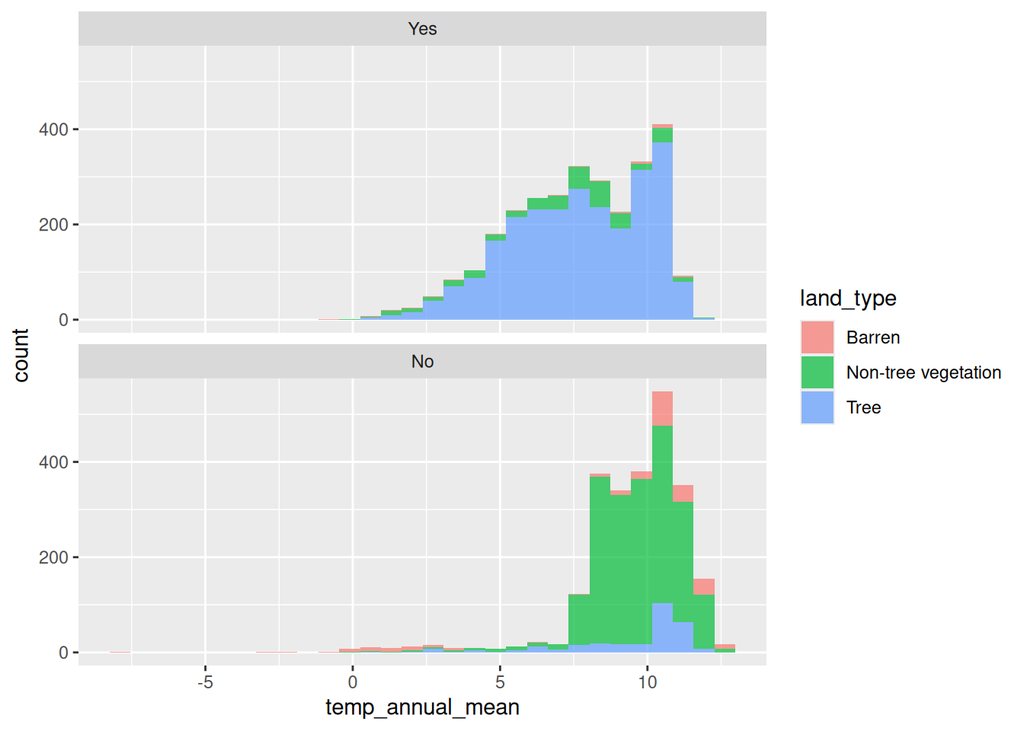

```r
ggplot(forest_train, aes(x = temp_annual_mean, fill = land_type)) +
  geom_histogram(alpha = 0.7) +
  facet_wrap(~ forested, ncol = 1)
```

We observe that that the majority of plots classified as not forested are of land type “Barren” or “Non-tree vegetation”, not “Tree”. The distribution of `temp_annual_mean` is centered at a higher value for non-forested plots than for forested, and it’s more concentrated around it’s center as well.

# Model 1: Custom choice of predictors

## Fit

Fit a model for classifying plots as forested or not based on a subset of predictors of your choice. Name the model `forested_custom_fit` and display a tidy output of the model.

```r
forested_custom_fit <- logistic_reg() |>
  fit(forested ~ precip_annual + elevation + temp_annual_mean, data = forest_train)

tidy(forested_custom_fit)
```

```
# A tibble: 4 × 5
  term             estimate std.error statistic   p.value
  <chr>               <dbl>     <dbl>     <dbl>     <dbl>
1 (Intercept)      -6.31    0.663         -9.52 1.77e- 21
2 precip_annual    -0.00170 0.0000664    -25.7  3.59e-145
3 elevation         0.00159 0.000257       6.20 5.52e- 10
4 temp_annual_mean  0.770   0.0559        13.8  4.01e- 43
```

## Interpret

Interpret the intercept (with respect to $\widehat{p}$) in the context of these data. Then, interpret one slope coefficient of your choice (with respect to the odds), again in the context of these data.

Intercept:

For a plot of land with 0 annual precipitation, 0 elevation, and an average annual temperature 0, we predict the probability that the plot is not forested is 0.00181323.

All else equal, we expect that for a one unit increase in annual precipitation, the predicted odds that a plot of land is not forested will decrease by a multiplicative factor of 0.9982989, on average.

```r
exp(-6.310830752) / (1 + exp(-6.310830752   ))
```

```
[1] 0.00181323
```

```r
levels(forest_train$forested)
```

```
[1] "Yes" "No"
```

```r
exp(-0.001702569)
```

```
[1] 0.9982989
```

## Predict

Predict for the testing data using this model.

```r
forest_aug <- augment(forested_custom_fit, new_data = forest_test)

forest_aug
```

```
# A tibble: 1,777 × 22
   .pred_class .pred_Yes .pred_No forested  year elevation eastness northness
   <fct>           <dbl>    <dbl> <fct>    <dbl>     <dbl>    <dbl>     <dbl>
 1 Yes            0.624   0.376   No        2005       164      -84        53
 2 Yes            0.986   0.0136  Yes       2005      2240      -67       -74
 3 Yes            0.983   0.0171  Yes       2005       787       66       -74
 4 Yes            0.997   0.00274 Yes       2005      1330       99         7
 5 Yes            0.999   0.00147 Yes       2005      1423       46        88
 6 Yes            0.994   0.00577 No        2005      1713      -66        75
 7 Yes            0.983   0.0175  Yes       2014       546      -92       -38
 8 Yes            0.998   0.00210 Yes       2014      1612       30       -95
 9 No             0.0620  0.938   No        2014       235        0      -100
10 No             0.121   0.879   No        2014       302      -31       -94
# ℹ 1,767 more rows
# ℹ 14 more variables: roughness <dbl>, tree_no_tree <fct>, dew_temp <dbl>,
#   precip_annual <dbl>, temp_annual_mean <dbl>, temp_annual_min <dbl>,
#   temp_annual_max <dbl>, temp_january_min <dbl>, vapor_min <dbl>,
#   vapor_max <dbl>, canopy_cover <dbl>, lon <dbl>, lat <dbl>, land_type <fct>
```

## Evaluate

Calculate the error rates (and their complements) for the testing data using this model.

```r
forest_aug |>
  count(forested, .pred_class) |>
  group_by(forested) |>
  mutate(prop = n / sum(n),
         decision = case_when(
           forested == "Yes" & .pred_class == "Yes" ~ "True Positive",
           forested == "Yes" & .pred_class == "No" ~ "False Negative",
           forested == "No" & .pred_class == "Yes" ~ "False Positive",
           forested == "No" & .pred_class == "No" ~ "True Negative"
         ))
```

```
# A tibble: 4 × 5
# Groups:   forested [2]
  forested .pred_class     n  prop decision
  <fct>    <fct>       <int> <dbl> <chr>
1 Yes      Yes           821 0.828 True Positive
2 Yes      No            170 0.172 False Negative
3 No       Yes           107 0.136 False Positive
4 No       No            679 0.864 True Negative
```

Another commonly used display of this information is a confusion matrix. Create this using the `conf_mat()` function. You will need to review the documentation for the function to determine how to use it.

```r
conf_mat(forest_aug,
         truth = forested,
         estimate = .pred_class)
```

```
          Truth
Prediction Yes  No
       Yes 821 107
       No  170 679
```

## Sensitivity, specificity, ROC curve

Calculate sensitivity and specificity and draw the ROC curve.

```r
forest_custom_roc <- roc_curve(forest_aug,
                               truth = forested,
                               .pred_Yes,
                               event_level = "first")

forest_custom_roc
```

```
# A tibble: 1,779 × 3
   .threshold specificity sensitivity
        <dbl>       <dbl>       <dbl>
 1  -Inf          0                 1
 2     0.0397     0                 1
 3     0.0422     0.00127           1
 4     0.0452     0.00254           1
 5     0.0486     0.00382           1
 6     0.0487     0.00509           1
 7     0.0490     0.00636           1
 8     0.0492     0.00763           1
 9     0.0493     0.00891           1
10     0.0502     0.0102            1
# ℹ 1,769 more rows
```

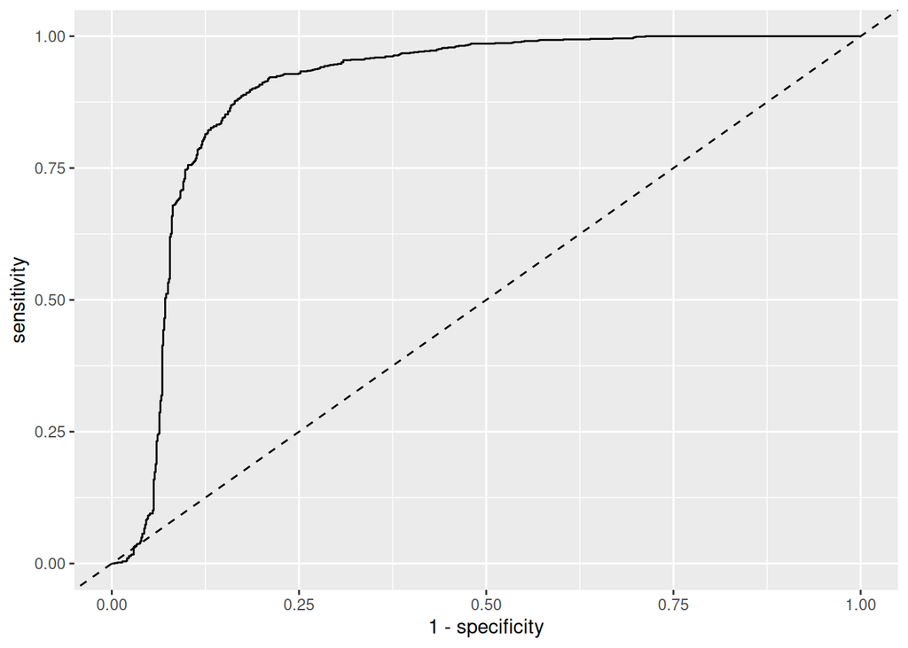

```r
ggplot(forest_custom_roc, aes(x = 1 - specificity, y = sensitivity)) +
  geom_path() +
  geom_abline(lty = "dashed")
```

# Model 2: All predictors

## Fit

Fit a model for classifying plots as forested or not based on all predictors available. Name the model `forested_full_fit` and display a tidy output of the model.

```r
forested_full_fit <- logistic_reg() |>
  fit(forested ~ ., data = forest_train)

tidy(forested_full_fit)
```

```
# A tibble: 20 × 5
   term                           estimate std.error statistic  p.value
   <chr>                             <dbl>     <dbl>     <dbl>    <dbl>
 1 (Intercept)                  -38.7      31.9         -1.22  2.24e- 1
 2 year                           0.0160    0.0149       1.07  2.85e- 1
 3 elevation                     -0.00195   0.000647    -3.02  2.57e- 3
 4 eastness                      -0.000166  0.000724    -0.230 8.18e- 1
 5 northness                      0.00223   0.000745     2.99  2.79e- 3
 6 roughness                     -0.00518   0.00148     -3.50  4.57e- 4
 7 tree_no_treeNo tree            1.12      0.135        8.27  1.31e-16
 8 dew_temp                      -0.102     0.177       -0.578 5.63e- 1
 9 precip_annual                 -0.000224  0.000105    -2.13  3.31e- 2
10 temp_annual_mean             -16.8      12.3         -1.36  1.73e- 1
11 temp_annual_min                0.810     0.104        7.81  5.51e-15
12 temp_annual_max                7.45      6.16         1.21  2.26e- 1
13 temp_january_min               8.14      6.15         1.32  1.86e- 1
14 vapor_min                     -0.000437  0.00354     -0.124 9.02e- 1
15 vapor_max                      0.00876   0.00128      6.86  6.79e-12
16 canopy_cover                  -0.0431    0.00369    -11.7   1.51e-31
17 lon                           -0.0948    0.0550      -1.72  8.46e- 2
18 lat                            0.119     0.110        1.08  2.80e- 1
19 land_typeNon-tree vegetation  -0.601     0.267       -2.25  2.45e- 2
20 land_typeTree                 -1.53      0.283       -5.39  7.07e- 8
```

## Predict

Predict for the testing data using this model.

```r
forest_full_aug <- augment(forested_full_fit, new_data = forest_test)
forest_full_aug
```

```
# A tibble: 1,777 × 22
   .pred_class .pred_Yes .pred_No forested  year elevation eastness northness
   <fct>           <dbl>    <dbl> <fct>    <dbl>     <dbl>    <dbl>     <dbl>
 1 Yes            0.916   0.0841  No        2005       164      -84        53
 2 Yes            0.834   0.166   Yes       2005      2240      -67       -74
 3 Yes            0.994   0.00578 Yes       2005       787       66       -74
 4 Yes            0.985   0.0152  Yes       2005      1330       99         7
 5 Yes            0.985   0.0153  Yes       2005      1423       46        88
 6 Yes            0.737   0.263   No        2005      1713      -66        75
 7 Yes            0.986   0.0143  Yes       2014       546      -92       -38
 8 Yes            0.982   0.0177  Yes       2014      1612       30       -95
 9 No             0.0607  0.939   No        2014       235        0      -100
10 No             0.0226  0.977   No        2014       302      -31       -94
# ℹ 1,767 more rows
# ℹ 14 more variables: roughness <dbl>, tree_no_tree <fct>, dew_temp <dbl>,
#   precip_annual <dbl>, temp_annual_mean <dbl>, temp_annual_min <dbl>,
#   temp_annual_max <dbl>, temp_january_min <dbl>, vapor_min <dbl>,
#   vapor_max <dbl>, canopy_cover <dbl>, lon <dbl>, lat <dbl>, land_type <fct>
```

## Evaluate

Calculate the error rates (and their complements) for the testing data using this model.

```r
forest_full_aug |>
  count(forested, .pred_class) |>
  group_by(forested) |>
  mutate(prop = n / sum(n),
         decision = case_when(
           forested == "Yes" & .pred_class == "Yes" ~ "True Positive",
           forested == "Yes" & .pred_class == "No" ~ "False Negative",
           forested == "No" & .pred_class == "Yes" ~ "False Positive",
           forested == "No" & .pred_class == "No" ~ "True Negative"
         ))
```

```
# A tibble: 4 × 5
# Groups:   forested [2]
  forested .pred_class     n   prop decision
  <fct>    <fct>       <int>  <dbl> <chr>
1 Yes      Yes           910 0.918  True Positive
2 Yes      No             81 0.0817 False Negative
3 No       Yes            82 0.104  False Positive
4 No       No            704 0.896  True Negative
```

## Sensitivity, specificity, ROC curve

Calculate sensitivity and specificity and draw the ROC curve.

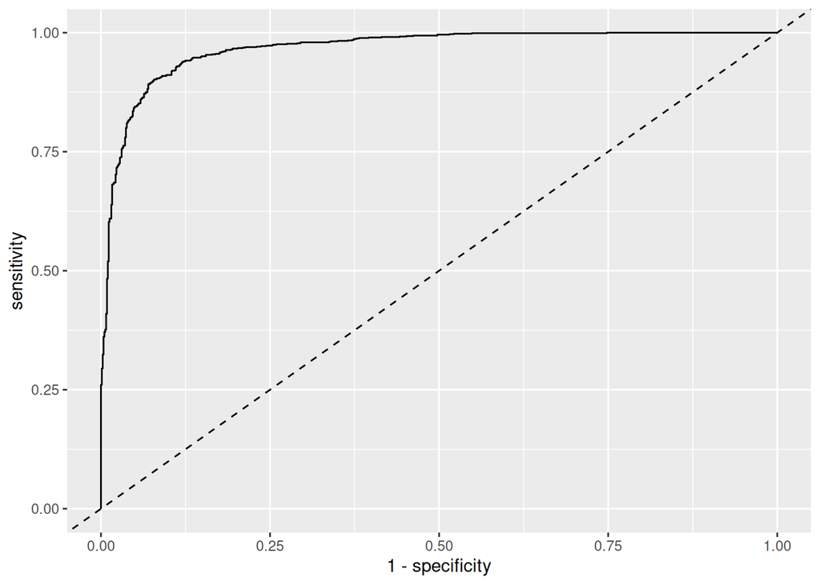

```r
forest_full_roc <- roc_curve(forest_full_aug,
                               truth = forested,
                               .pred_Yes,
                               event_level = "first")

ggplot(forest_full_roc, aes(x = 1 - specificity, y = sensitivity)) +
  geom_path() +
  geom_abline(lty = "dashed")
```

# Model 1 vs. Model 2

Plot both ROC curves and articulate how you would use them to compare these models.

```r
forest_custom_roc <- forest_custom_roc |>
  mutate(model = "custom")
forest_custom_roc
```

```
# A tibble: 1,779 × 4
   .threshold specificity sensitivity model
        <dbl>       <dbl>       <dbl> <chr>
 1  -Inf          0                 1 custom
 2     0.0397     0                 1 custom
 3     0.0422     0.00127           1 custom
 4     0.0452     0.00254           1 custom
 5     0.0486     0.00382           1 custom
 6     0.0487     0.00509           1 custom
 7     0.0490     0.00636           1 custom
 8     0.0492     0.00763           1 custom
 9     0.0493     0.00891           1 custom
10     0.0502     0.0102            1 custom
# ℹ 1,769 more rows
```

```r
forest_full_roc <- forest_full_roc |>
  mutate(model = "full")

forest_roc <- rbind(forest_custom_roc, forest_full_roc)
forest_roc
```

```
# A tibble: 3,558 × 4
   .threshold specificity sensitivity model
        <dbl>       <dbl>       <dbl> <chr>
 1  -Inf          0                 1 custom
 2     0.0397     0                 1 custom
 3     0.0422     0.00127           1 custom
 4     0.0452     0.00254           1 custom
 5     0.0486     0.00382           1 custom
 6     0.0487     0.00509           1 custom
 7     0.0490     0.00636           1 custom
 8     0.0492     0.00763           1 custom
 9     0.0493     0.00891           1 custom
10     0.0502     0.0102            1 custom
# ℹ 3,548 more rows
```

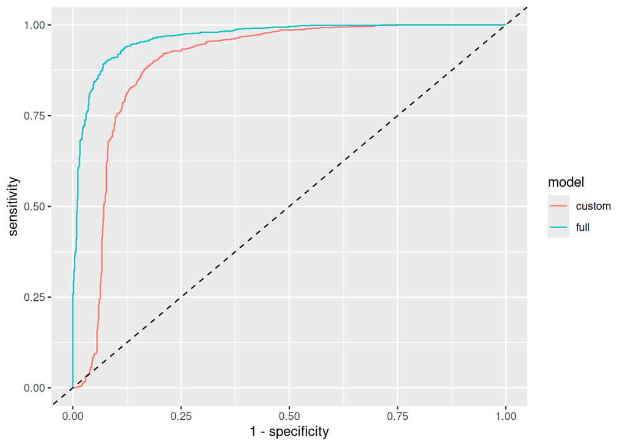

```r
ggplot(forest_roc, aes(x = 1 - specificity, y = sensitivity, color = model)) +
  geom_path() +
  geom_abline(lty = "dashed")
```

We would choose to favor the model with the larger AUC; in this case, this is the full model.

```r
forest_full_auc <- roc_auc(forest_full_aug,
                               truth = forested,
                               .pred_Yes,
                               event_level = "first")
forest_full_auc
```

```
# A tibble: 1 × 3
  .metric .estimator .estimate
  <chr>   <chr>          <dbl>
1 roc_auc binary         0.967
```

```r
forest_custom_auc <- roc_auc(forest_aug,
                               truth = forested,
                               .pred_Yes,
                               event_level = "first")
forest_custom_auc
```

```
# A tibble: 1 × 3
  .metric .estimator .estimate
  <chr>   <chr>          <dbl>
1 roc_auc binary         0.895
```